# 2017 SEC vs PAC 12 Softball

Lauren Blose

## Introduction

1. I hypothesize that the SEC will have a higher overall batting average than the PAC-12.
2. I hypothesize that the SEC will have a higher overall slugging percentage than the PAC-12.
3. I hypothesize that there will be a significant and positive relationship between batting averages and slugging percentages.

## Methods

In order to collect my data, I went to the team website for each of the teams that I decided to use in my project. I recorded the batting average and slugging percentage for 8 players of each of the teams that listed earlier. The batting average of each player is a ratio of a batter’s safe hits per official at bats, and slugging percentage is the total number of bases covered by a player divided by the number of at bats. These were calculated by the teams and were published online. For my first 2 tests to explore my first 2 hypotheses, I used boxplots to compare batting averages and slugging percentages to the conferences. For my third test, I used a scatterplot with a linear regression for batting average vs slugging percentage. The baseline group in the first 2 regression tables is the PAC-12 and that of the third test is slugging percentage.

## Results

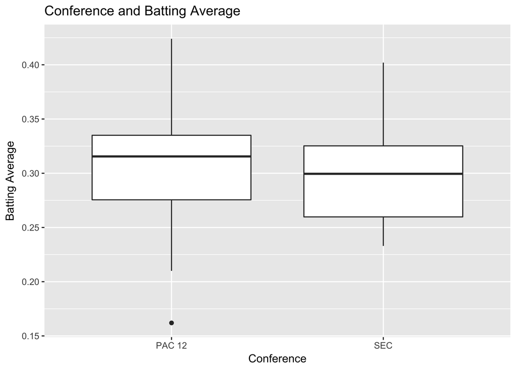

```
##
## Call:
## lm_basic(formula = batting_avg ~ 1 + conference, data = softball)
##
## Residuals:
##       Min        1Q    Median        3Q       Max
## -0.145312 -0.035271  0.004187  0.027688  0.116688
##
## Coefficients:
##                Estimate     2.5 % 97.5 %
## (Intercept)    0.307313  0.293693  0.321
## conferenceSEC -0.009042 -0.028303  0.010
##
## Residual standard error: 0.04752 on 94 degrees of freedom
## Multiple R-squared:  0.009157,   Adjusted R-squared:  -0.001383
## F-statistic: 0.8687 on 1 and 94 DF,  p-value: 0.3537
```

The above plot and regression table indicate that batting average does not differ significantly between the SEC and PAC-12.

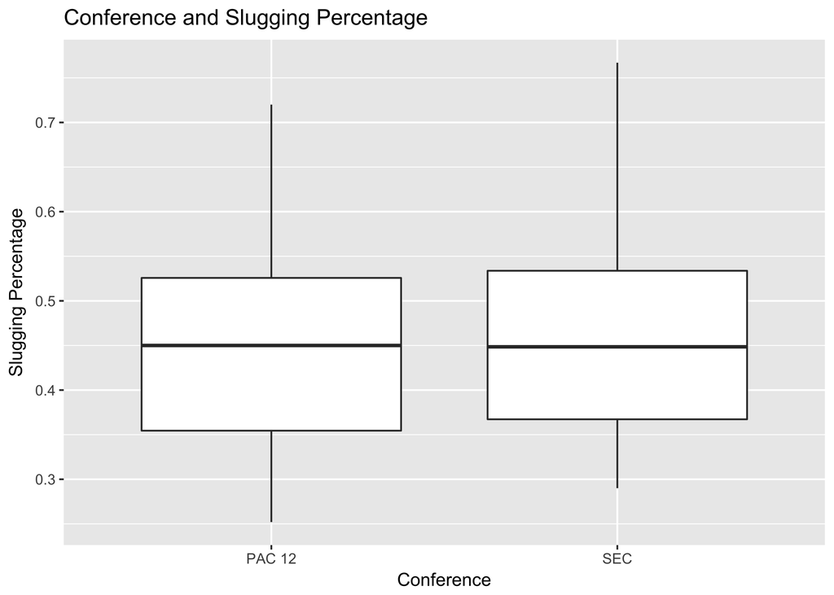

```
##
## Call:
## lm_basic(formula = slugging_perc ~ 1 + conference, data = softball)
##
## Residuals:
##       Min        1Q    Median        3Q       Max
## -0.198167 -0.093729 -0.006375  0.075167  0.308417
##
## Coefficients:
##                Estimate     2.5 % 97.5 %
## (Intercept)    0.450167  0.418465  0.482
## conferenceSEC  0.008417 -0.036416  0.053
##
## Residual standard error: 0.1106 on 94 degrees of freedom
## Multiple R-squared:  0.001476,   Adjusted R-squared:  -0.009147
## F-statistic: 0.1389 on 1 and 94 DF,  p-value: 0.7102
```

The above plot and regression table indicate that slugging percentage does not differ significantly between the SEC and PAC-12.

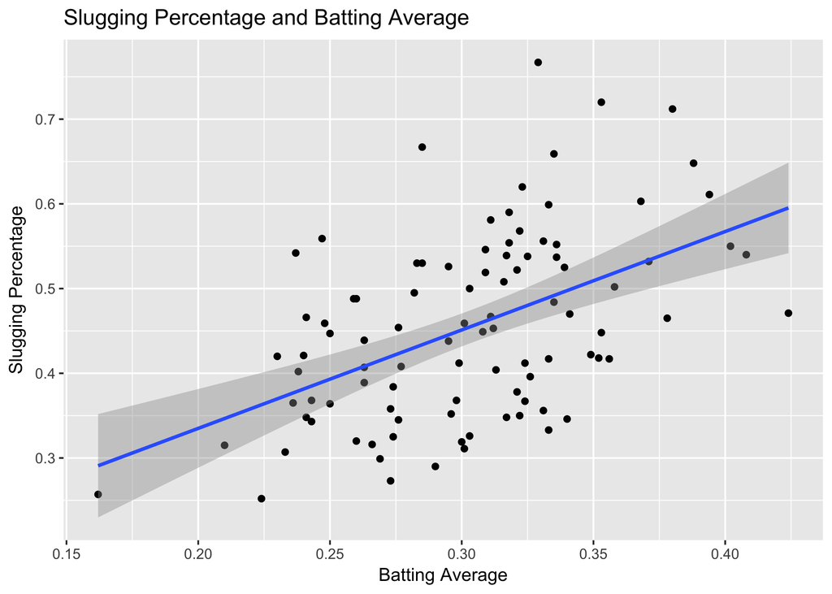

```
##
## Call:
## lm_basic(formula = slugging_perc ~ 1 + batting_avg, data = softball)
##
## Residuals:
##      Min       1Q   Median       3Q      Max
## -0.15647 -0.07889 -0.01160  0.06816  0.28218
##
## Coefficients:
##             Estimate    2.5 % 97.5 %
## (Intercept)  0.10259 -0.02334  0.229
## batting_avg  1.16179  0.75086  1.573
##
## Residual standard error: 0.0958 on 94 degrees of freedom
## Multiple R-squared:  0.2511, Adjusted R-squared:  0.2431
## F-statistic: 31.51 on 1 and 94 DF,  p-value: 1.998e-07
```

## Conclusions

Test 1, which compared the batting averages of the SEC and PAC-12 to one another, resulted in a slightly negative slope. However, because this value was -0.009042 and the other values in the regression table were negative and positive, the difference between the batting averages of the SEC and PAC-12 are insignificant. Test 2 compared the slugging percentages of the SEC and PAC-12 and resulted in a positive slope of 0.008417. Similarly to Test 1, the other values in the regression table were negative and positive, making the difference between slugging percentages of the SEC and PAC-12 insignificantly different. Test 3, as I predicted, rendered a significant and positive relationship between batting average and slugging percentage in that slugging percentage tends to generally increase with batting average.

## References

http://www.lsusports.net/src/data/lsu/assets/docs/sb/17stats/teamcume.htm?DB_OEM_ID=5200

http://www.auburntigers.com/sports/w-softbl/stats/2016-2017/teamcume.html

http://floridagators.com/documents/2017/6/20//2017_SB_Overall_Final.pdf?id=18080

http://www.arkansasrazorbacks.com/wp-content/uploads/2017/05/2017-ARKSB-Season-Statistics_0520.pdf

https://thesundevils.com/documents/2017/3/28/Overall_Season.pdf?path=softball

http://goducks.com/cumestats.aspx?path=softball&year=2017

http://gostanford.com/cumestats.aspx?path=softball&year=2017

https://static.osubeavers.com/custompages/SOFTBALL/SB2017/HTML/teamcume.htm

https://s3.amazonaws.com/rolltide.com/documents/2017/2/10/season_stats.pdf

http://ukathletics.com/sports/2017/11/9/2017-softball-stats.aspx

http://static.pac-12.com/sports/softball/stats/2016-17/HTML/ucla.htm#team.mlb

http://static.pac-12.com/sports/softball/stats/2016-17/HTML/cal.htm#team.mlb